# Jupyter MATLAB Kernel 설정하기

Written by JunPyo Park

# Table of Contents

윈도우 환경에서 주피터 노트북과 매트랩 커널을 연결하는 방법을 정리해 보았습니다. 주피터 노트북에 매트랩을 연결하면 GUI 환경에서 편리하게 작업이 가능하고 중간중간 python 코드 셀도 사용이 가능합니다.

## 매트랩 커널을 사용할 가상환경 생성

### 관리자 권한으로 터미널 실행

가상환경을 만들기 전에 터미널을 우클릭 하여 관리자 권한으로 실행합니다.

[figure not shown]

### 가상환경 만들기

설치된 매트랩 버젼에 따라 호환되는 파이썬 버젼이 다르기 때문에 아래 테이블을 확인해서 호환 되는 파이썬 버젼으로 가상환경을 만들어 주세요

버젼 확인: https://www.mathworks.com/content/dam/mathworks/mathworks-dot-com/support/sysreq/files/python-compatibility.pdf

[figure not shown]

저는 MATLAB R2021b 가 설치되어 있습니다.

[figure not shown]

호환되는 파이썬 버젼을 사용하여 matlab 이라는 콘다 가상환경을 만들어 주었습니다.

```
conda create -n matlab python=3.8
conda activate matlab
```

### 가상환경에 주피터 설치

```
pip install jupyter notebook
```

만들어진 가상환경에 주피터 노트북을 설치합니다.

## [Python용 MATLAB Engine API 설치](https://kr.mathworks.com/help/matlab/matlab_external/install-the-matlab-engine-for-python.html)

그 다음 Python용 MATLAB Engine API를 설치해야 합니다. 설치 과정은 다음과 같습니다.

### MATLAB Root 디렉토리 확인

매트랩을 실행하여 명령 창에 matlabroot 라고 입력하면 다음과 같이 경로가 출력됩니다.

[figure not shown]

### Engine API 설치

가상환경을 들어간 터미널에서 matlabroot\extern\engines\python 로 경로를 이동하여 setup.py 파일을 설치 합니다.

```
cd C:\Program Files\MATLAB\R2021b\extern\engines\python

python setup.py install
```

[figure not shown]

## Matlab kernel for Jupyter 설치

MATLAB Kernel github repo: https://github.com/Calysto/matlab_kernel

만들어둔 matlab 가상환경에 matlab_kernel을 설치합니다.

```
pip install matlab_kernel
```

[figure not shown]

## 주피터 노트북 실행

matlab 가상환경에서 주피터 노트북을 실행하면 Matlab 커널이 생긴걸 확인 할 수 있습니다.

[figure not shown]

Matlab 커널로 파일을 만들면 아래와 같이 연동됨을 확인 할 수 있습니다.

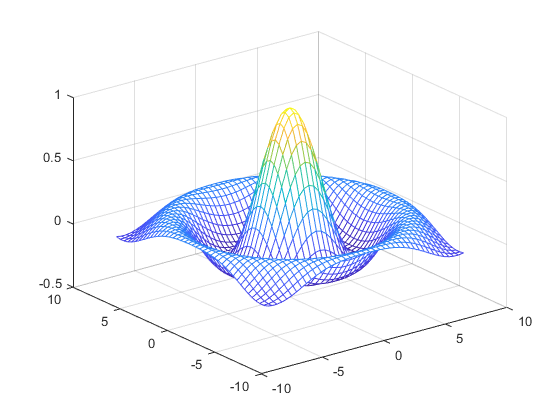

```matlab
tx = linspace (-8, 8, 41);
ty = tx;
[xx, yy] = meshgrid (tx, ty);
r = sqrt (xx .^ 2 + yy .^ 2) + eps;
tz = sin (r) ./ r;

%plot inline
mesh(tx, ty, tz);
```

```matlab
tx
```

```
tx =

  1 ~ 15번 열

   -8.0000   -7.6000   -7.2000   -6.8000   -6.4000   -6.0000   -5.6000   -5.2000   -4.8000   -4.4000   -4.0000   -3.6000   -3.2000   -2.8000   -2.4000

  16 ~ 30번 열

   -2.0000   -1.6000   -1.2000   -0.8000   -0.4000         0    0.4000    0.8000    1.2000    1.6000    2.0000    2.4000    2.8000    3.2000    3.6000

  31 ~ 41번 열

    4.0000    4.4000    4.8000    5.2000    5.6000    6.0000    6.4000    6.8000    7.2000    7.6000    8.0000
```

코드 셀에 `%%pyton`을 입력하면 파이썬 명령을 실행 가능 합니다.

```matlab
%%python
print("읽어 주셔서 감사합니다.")
```

```
읽어 주셔서 감사합니다.
```